# NormalDistributionExampleProblems

### A bit on normal distributions - Boby Mass Index (BMI) Analysis

```python
import matplotlib.pyplot as plt
from scipy.stats import norm
import numpy as np
import pandas as pd
%matplotlib inline
```

Suppose that the distribution of BMI values for 18 year old males in the US follows a normal distribution with mean 20.0 ($kg/m^2$) and standard deviation ($\sigma$) of 5.0 ($kg/m^2$). Suppose you are a physician and you have screened 3 patients. Answer the following questions

- a. Male 1 had a BMI of 25.0. His BMI was above average by how many $\sigma$?
- b. Male 2 had a BMI of 23.5. He His BMI was above average by how many $\sigma$?
- c. Male 3 had a BMI of that was .95 $\sigma$ below the average. What was his BMI measure?
- d. Estimate a range of “normal” BMI values, ie: a range that contains the middle 95% of the values in the population of 18 year old males.
- e. Not surprisingly, perhaps, the actual distribution of BMI values among 18 year old males is right skewed (slightly, not heavily so). Given this fact, what additional summary statistics would be necessary to properly estimate the interval in part d?

```python
#contruct a normal distribution function with specified mean and standard deviation
def normal(x,mu,sigma):
    factor = 1/(np.sqrt(2*np.pi*sigma**2))
    fx = np.exp(-(x-mu)**2/(2*sigma**2))
    return factor*fx
print("Test for correctness: ", normal(1,0,1)==norm.pdf(1))
```

```
Test for correctness:  True
```

**a. Male 1 had a BMI of 25.0. His BMI was above average by how many $\sigma$?**
This is very straightforward. We simply need to caluculate the seperation from the mean and normalize the result by $\sigma$. i.e. $$ \frac{(x - \bar x)}{\sigma} = \frac{(25 - 20)}{5} = 1$$

Hence, a male with a BMI of 25 is 1 standard deviation above the average BMI.

**b. Male 2 had a BMI of 23.5. He His BMI was above average by how many $\sigma$?** Similarly, the answer here would be $$\frac{(23.5 - 20)}{5} = 0.7$$

**c. Male 3 had a BMI of that was .95 $\sigma$ below the average. What was his BMI measure?**
In this case we have $$20 - x = 0.95\sigma$$ $$x = 20-0.95*5 = 15.25 kg/m^2$$

**d. Estimate a range of “normal” BMI values, ie: a range that contains the middle 95% of the values in the population of 18 year old males.**  
This is also straightforward. We can use the [68-95-99.7 rule](https://en.wikipedia.org/wiki/68%E2%80%9395%E2%80%9399.7_rule) for normal distributions according to which 95% of the values will fall between 2 standard deviation ($\sigma$) from the mean (both sides). Since $\sigma=5$, $2\sigma$ below the mean is 20-2x5 = 10 and $2\sigma$ above is 20+2x5 = 30.  
Hence, **the normal BMI range is between 10 and 30**. The plot below shows the desired area shaded in red.

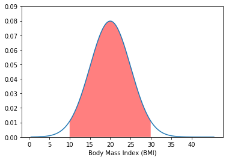

```python
#Make a plot of the normale distribution with mean 20 and sigma = 5
mu, sigma = 20, 5
x = np.linspace(start=0.5,stop=45.5,num=1000)
y = [normal(bmi,mu,sigma) for bmi in x]
fig, ax = plt.subplots()
ax.plot(x,y)
ticks=plt.xticks(np.arange(0, 45, step=5))
plt.ylim(0,0.09)
plt.xlabel("Body Mass Index (BMI)")

#Let's shade the region under the curve between x=15 and x=25
x_shade = np.arange(10, 30, 1/20.)
y_shade = [normal(bmi,mu,sigma) for bmi in x_shade]
ax.fill_between(x_shade,y_shade, facecolor='red', alpha=0.5)
plt.show()
```

More about this coming ...